##R as a calculator

You can also use R as a calculator:

```r
1+1
```

```
## [1] 2
```

```r
5^2
```

```
## [1] 25
```

```r
487/34
```

```
## [1] 14.32353
```

There are several different tabs that you see in RStudio. Here are a few that you will encounter (though there are more!) 1. The Console is where all of your commands and numeric results are displayed. If you have an error, the words will appear in red in the Console. 2. The History Tab keeps track of all of the commands you have entered into the console 3. The Plots Tab will display your plots, which you can zoom in on, export, or go to previous plots using the arrows

R has many built in functions:

```r
pi
```

```
## [1] 3.141593
```

```r
cos(pi)
```

```
## [1] -1
```

```r
factorial(5)
```

```
## [1] 120
```

```r
exp(1)
```

```
## [1] 2.718282
```

```r
sqrt(169)
```

```
## [1] 13
```

R is case sensitive. Run the chunk below, and then try it again with `Log` instead of `log`

```r
log(exp(7))
```

```
## [1] 7
```

##Asking for help

As you could see from above, the `log` function has a default to be the natural log. How can you find the log to base 2? How can you find out what a function does? Try the code below and see if you can answer these questions. Then try to find the log to the base 2 of 64.

```r
?log

#ENTER YOUR COMMAND HERE
```

##VECTORS

R makes working with vectors very easy! The command `a:b` creates a vector of numbers from `a` to `b`. Try entering in `1:45` in the chunk below. Also try `-7:14`

```r
#ENTER YOUR COMMANDS HERE
```

Another way to create vectors is by using the `seq(a,b,c)` command. Try using the `seq(a,b,c)` command below filling in different numbers for a, b, and c. Can you figure out what these arguments tell the `seq` command to do?

```r
#ENTER YOUR SEQ COMMANDS HERE


#ENTER IN YOUR EXPLANATION FOR HOW TO USE THE SEQ COMMAND HERE
```

The command `x <- c(2,3,5,7,11)` will generate a vector with the variable name `x`. The assignment operator is `<-`. The `c` stands for concatenate. Use this to make a vector with six ellements that you name `cat`:

```r
cat<-NULL #this just makes an empty vector, DELETE 'NULL'  and INSERT YOUR COMMAND HERE
```

Now we want to add 3 more elements to the vector `cat`:

```r
cat<-c(cat,4, 5, 6 )
cat
```

```
## [1] 4 5 6
```

Elements of vectors are accessed with `[ ]`.

```r
cat[2]
```

```
## [1] 5
```

```r
cat[1:3]
```

```
## [1] 4 5 6
```

```r
cat[c(2,4)]
```

```
## [1]  5 NA
```

The vector `cat` only has 3 elements, so when we asked for the fourth element R will return `NA`.

With numeric vectors you can add, subtract and do all the usual mathematical operations, treating the entire vector as a single object.

```r
cat
```

```
## [1] 4 5 6
```

```r
cat+1
```

```
## [1] 5 6 7
```

```r
cat+pi
```

```
## [1] 7.141593 8.141593 9.141593
```

```r
cat*3
```

```
## [1] 12 15 18
```

```r
cat^2
```

```
## [1] 16 25 36
```

```r
2^cat
```

```
## [1] 16 32 64
```

```r
dog<-cat*2

dog*cat
```

```
## [1] 32 50 72
```

```r
dog+cat
```

```
## [1] 12 15 18
```

```r
dog/cat
```

```
## [1] 2 2 2
```

##Operations on Vectors

Notice that when we add a single number to a vector, that number gets added to each element of the vector. But when two vectors of the same length are added to each other, then corresponding elements are added together. This applies to most binary operations.

Some common operations on vectors are: (i) `sum` the elements, (ii) take the average (`mean`), and (iii) find the `length`.

```r
tiger <- 1:1000
sum(tiger)
```

```
## [1] 500500
```

```r
mean(tiger)
```

```
## [1] 500.5
```

```r
length(tiger)
```

```
## [1] 1000
```

The `sample` command is one of many commands that lets you generate random numbers. This is particularly helpful for Probability and Statistics! The following code picks one number from the integers 1 to 10:

```r
sample(1:10,1)
```

```
## [1] 1
```

To simulate ten rolls of a six-sided die with labels {1, 2, 3, 4, 5, 6}, type

```r
roll <- sample(1:6,10,replace=TRUE)
roll
```

```
##  [1] 5 5 1 6 1 2 6 5 5 6
```

The command `roll == 2` creates a TRUE-FALSE vector identifying where the twos are in the original `roll` vector. We can treat this TRUE-FALSE vector as if it consists of zeros and ones. By summing that vector we count the number of twos:

```r
sum(roll==2)
```

```
## [1] 1
```

The following one-line command simulates rolling 600 dice and counting the number of twos that appear. After you type the command once, hit the up-arrow key to repeat. By repeating over and over again, you begin to get a feel for the typical behavior of the number of twos in 600 dice rolls:

```r
sum(2==sample(1:6,600,replace=TRUE))
```

```
## [1] 101
```

##Plots and Graphs

To graph functions and plot data, use `plot`. This workhorse command has enormous versatility. Here is a simple plot comparing two vectors:

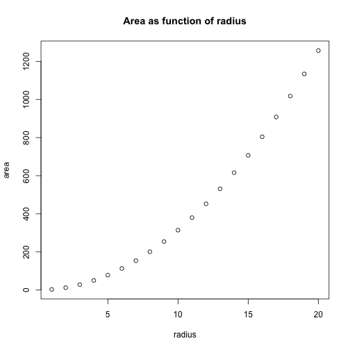

```r
radius <- 1:20
area <- pi*radius^2
plot(radius,area, main="Area as function of radius")
```

To graph smooth functions you can also use the curve command:

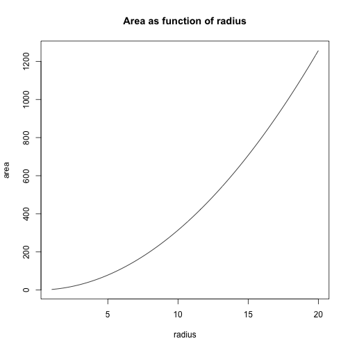

```r
curve(pi*x^2,1,20,xlab="radius",ylab="area",main="Area as function of radius")
```

The syntax is `curve(expr,from=,to=)`, where `expr` is some expression that is a function of x.

##Larger Chunks of Code

R can be used to do more complicated commands, and run several commands of code. In the block of code below, we simulate flipping 1000 coins and plot the running proportion of heads from one to 1000. Let zero represent tails and one represent heads. A 1000-element coin flip vector of zeros and ones is stored in the variable `coinflips`. The `cumsum` command generates a cumulative sum and stores the resulting vector in heads. The kth element of `heads` is equal to the number of ones in the first k positions of `coinflips`, that is, the number of heads in the first k coin flips. Then `prop` stores the proportion of heads in the first k coin flips. Finally, the running proportions are plotted. We see that the proportion of heads appear to converge to one-half.

```r
# Coin flips
n <- 1000 # Number of coin flips
coinflips <- sample(0:1,n,replace=TRUE)
coinflips
```

[output not shown]

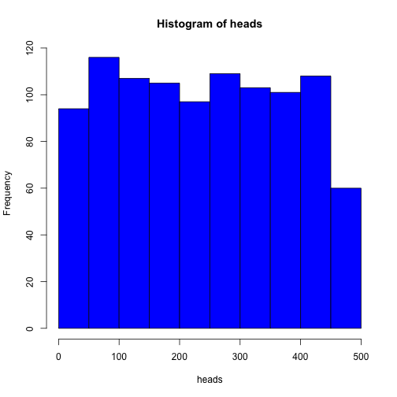

```r
heads <- cumsum(coinflips)
hist(heads,col="blue")
```

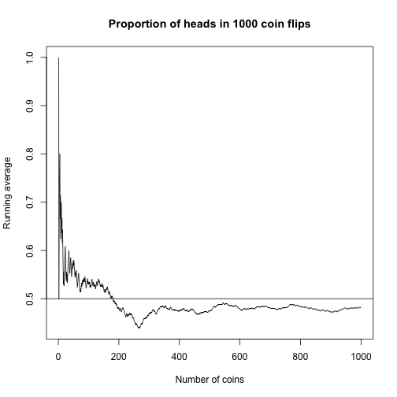

```r
prop <- heads/(1:n)
plot(1:n,prop,type="l",xlab="Number of coins",
ylab="Running average",
main="Proportion of heads in 1000 coin flips")
abline(h=0.5)
```